# Tutorial_workshop_GROUP1.ipynb

Author

*A story created @ Visualising Climate 2026, Bologna*

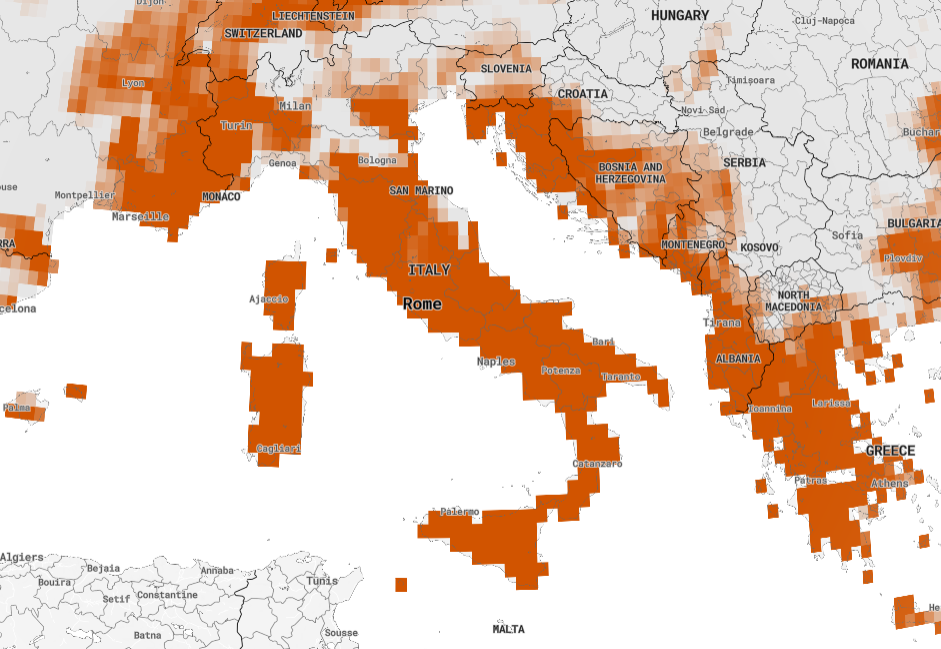

Screeshot of the Extreme Max temprature component from the [E3CI Data Station](https://datastation.climateindex.eu/en)

In the second half of July 2023 a long heatwave hit southern Italy: Palermo reached about 47 °C on 24 July, its highest temperature on record, and wildfires closed its airport. How extreme was it, and how does it fit into the last 46 years?

### How to read the E3CI

- For every **month**, **place** and **component** (heat, cold, drought, rain, wind, hail, fire), the E3CI compares that month with the **same month in 1981–2010**: 0 = a normal month, 1 = one standard deviation above normal.
- **Values above 1 are extreme**, in three classes: 1–2, 2–3, above 3 (the darker the colour, the more extreme).
- Because every month is compared with itself, an extreme in winter or autumn means unusual *for that season*. For example, a heat E3CI of 1.2 in July and of 2.5 in January does not mean that January was hotter than July. It means that January was much further from what is usual for January than July was from what is usual for July.

*Data: [E3CI – European Extreme Events Climate Index](https://www.climateindex.eu), from the Copernicus [ERA5 reanalysis](https://cds.climate.copernicus.eu/datasets/reanalysis-era5-single-levels?tab=overview).*

## An overview of extreme weather events in Europe from 1981 to the present day

### Each hazard has its own story

[figure not shown]

E3CI tracks seven climate hazards, and they do not all move in the same direction. One clearly stands out: **extreme maximum temperatures**. Until the early 2000s the orange bars stay mostly below the 1981–2010 average; in the last fifteen years almost every bar towers above it, and the most recent years are the highest of the whole series. Wildfires, closely linked to heat, follow a similar path, with sharp peaks in recent years. Extreme cold and hail go the other way, becoming rarer. Drought, heavy rain and wind change much less. In short, **heat has grown more than any other hazard**, by a factor of about 3.5. This is why our story follows the heat. But when in the year does it strike? (2026 data up to September.)

### When in the year?

[figure not shown]

In this plot is important to note that the area of a petal, not its length, shows the share: a petal twice as long means about four times as many extreme months. In 1981–2010 the rose for extreme maximum temperatures is small and regular, just above the 10% circle in every month. In 2011–2026 almost **every petal reaches or exceeds the 40% circle, with no clear summer peak:** February, April, October and November are as affected as July. On average, the share of extreme-heat country-months rises from 11% to 37%, and **the dark outer band shows that many of them exceed E3CI 3**. The opposite happens for extreme cold, which shrinks mostly below 10% (from 11% to 6.8% on average), and for hail (from 14% to 9.5%). Wildfires almost triple, from 5.5% to 16%, growing especially in spring and summer. **Extreme heat is no longer a summer event**: it is now spread across the whole year. But where in Europe does it hit?

### Compare countries in Europe: who is hit the hardest in July over the years?

[figure not shown]

Until 2010, extreme Julys are isolated episodes, appearing only here and there. After 2010 the grid changes colour: extreme cells become increasingly frequent and, since 2022, almost the rule. Not all countries are affected equally: the Balkans and Central Europe top the ranking, and Italy, with 12 extreme Julys since 1981, is among the most affected countries. July 2023 was extreme in 18 of the 45 countries, fewer than in July 2025 (39), but it was one of the most intense in the south: above 3 in Italy, Malta, Greece, Albania and Croatia.

### One map per year

[figure not shown]

Each map is a July, from 1981 to today: read it like a comic strip, left to right and top to bottom. In the first rows Europe is almost entirely grey, and extreme heat appears only occasionally. From the 2000s onwards the orange patches become more frequent, wider and darker, hitting different areas each time, from Scandinavia to the Balkans. Extreme heat is no longer a local exception but a phenomenon that moves and spreads across the continent.

## Zoom in: Italy

### The barcode of extremes

[figure not shown]

One row per component, one cell per year. In Italy the heat row changes the most: 27 extremely hot months in the three decades 1981–2010, 84 in the sixteen years since 2011.

### Heat and cold weather, region by region

[figure not shown]

The two indicators move in opposite directions: extreme events linked to high temperatures are increasing, while those linked to extreme low temperatures are becoming rarer and less widespread. The numbers make it clear: comparing the first and the last decade, extreme heat months rise from 95 to 703, while extreme cold months fall from 151 to 17. In the 1980s blue and orange dots alternate; today the chart is almost entirely orange, in all 20 regions.

### Month by month, and the records

[figure not shown]

Top: only 4 months above 3 in 1981–2010, 31 since 2011. Bottom: Italy has set six heat records since 1991, where a stable climate would give about 1.5. July 2023 reached 6.2 for Italy as a whole, the second most extreme July, but not a record: October 2022 and October 2023 were even further from normal for their season.

### The event: Sicily, July 2023

[figure not shown]

Sicily reached 13.5 in July 2023, its second most extreme July after July 2026 and its third most extreme month since 1981. On the right, the most affected regions of Europe that month: only Campania was higher (18.6).